# Multidimensional Scaling (MDS) Examples

Statistics 185

10/10/2019

This document contains two examples Multidimensional Scaling: one on metric MDS and a second on nonmetric MDS.

## Metric MDS

### US cities

```
##               Atlanta Chicago Denver Houston LosAngeles Miami NewYork
## Chicago           587
## Denver           1212     920
## Houston           701     940    879
## LosAngeles       1936    1745    831    1374
## Miami             604    1188   1726     968       2339
## NewYork           748     713   1631    1420       2451  1092
## SanFrancisco     2139    1858    949    1645        347  2594    2571
## Seattle          2182    1737   1021    1891        959  2734    2408
## Washington.DC     543     597   1494    1220       2300   923     205
##               SanFrancisco Seattle
## Chicago
## Denver
## Houston
## LosAngeles
## Miami
## NewYork
## SanFrancisco
## Seattle                678
## Washington.DC         2442    2329
```

The goal of MDS is to to reconstruct the configuration of $n$ points, in this case cities, using information about the distances between them.

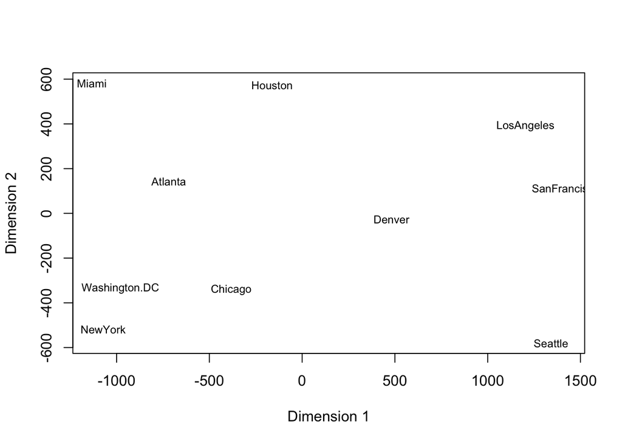

If we rotate this image 180 degrees we see a map which aligns with the map of the US

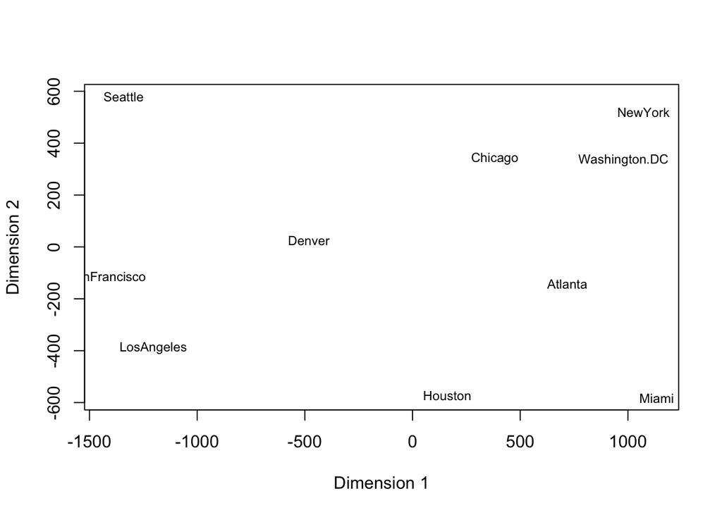

### European cities

We can also consider a collection of 21 European cities

```
##                 Athens Barcelona Brussels Calais Cherbourg Cologne
## Barcelona         3313
## Brussels          2963      1318
## Calais            3175      1326      204
## Cherbourg         3339      1294      583    460
## Cologne           2762      1498      206    409       785
## Copenhagen        3276      2218      966   1136      1545     760
## Geneva            2610       803      677    747       853    1662
## Gibraltar         4485      1172     2256   2224      2047    2436
## Hamburg           2977      2018      597    714      1115     460
## Hook of Holland   3030      1490      172    330       731     269
## Lisbon            4532      1305     2084   2052      1827    2290
## Lyons             2753       645      690    739       789     714
## Madrid            3949       636     1558   1550      1347    1764
## Marseilles        2865       521     1011   1059      1101    1035
## Milan             2282      1014      925   1077      1209     911
## Munich            2179      1365      747    977      1160     583
## Paris             3000      1033      285    280       340     465
## Rome               817      1460     1511   1662      1794    1497
## Stockholm         3927      2868     1616   1786      2196    1403
## Vienna            1991      1802     1175   1381      1588     937
##                 Copenhagen Geneva Gibraltar Hamburg Hook of Holland Lisbon
## Barcelona
## Brussels
## Calais
## Cherbourg
## Cologne
## Copenhagen
## Geneva                1418
## Gibraltar             3196   1975
## Hamburg                460   1118      2897
## Hook of Holland        269    895      2428     550
## Lisbon                2971   1936       676    2671            2280
## Lyons                 1458    158      1817    1159             863   1178
## Madrid                2498   1439       698    2198            1730    668
## Marseilles            1778    425      1693    1479            1183   1762
## Milan                 1537    328      2185    1238            1098   2250
## Munich                1104    591      2565     805             851   2507
## Paris                 1176    513      1971     877             457   1799
## Rome                  2050    995      2631    1751            1683   2700
```

[output cut: 8 more lines]

```
## Copenhagen
## Geneva
## Gibraltar
## Hamburg
## Hook of Holland
## Lisbon
## Lyons
## Madrid           1281
## Marseilles        320   1157
## Milan             328   1724        618
## Munich            724   2010       1109   331
## Paris             471   1273        792   856    821
## Rome             1048   2097       1011   586    946  1476
## Stockholm        2108   3188       2428  2187   1754  1827 2707
## Vienna           1157   2409       1363   898    428  1249 1209      2105
```

A 2-dimensional reconstruction using MDS gives the map

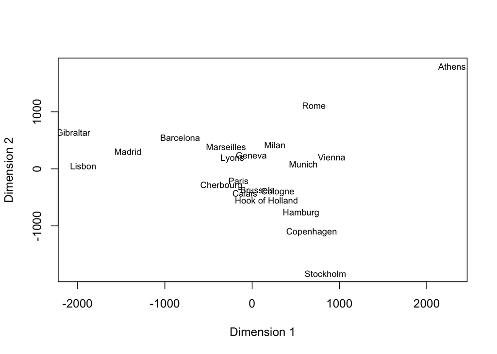

which again, has a different orientation than the traditional perspective take in the US/Europe. Flipping the second dimension gives

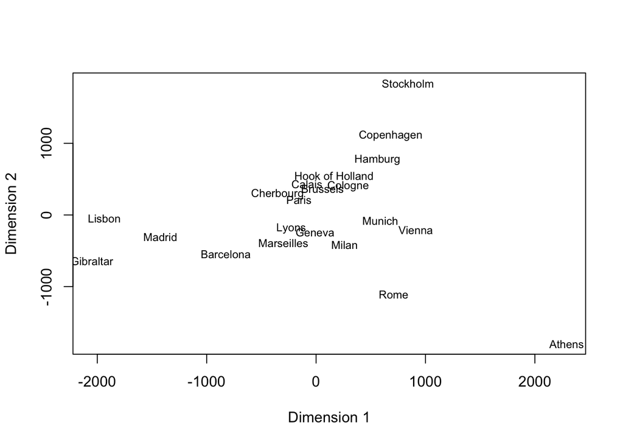

### Global cities

Distances, given by length of flights from one city the next (geodesic or great circle distance), are shown for a set of 18 cities from around the globe.

```
##             Beijing Cape Town Hong Kong Honolulu London Melbourne
## Beijing           0     12947      1972     8171   8160      9093
## Cape Town     12947         0     11867    18562   9635     10388
## Hong Kong      1972     11867         0     8945   9646      7392
## Honolulu       8171     18562      8945        0  11653      8862
## London         8160      9635      9646    11653      0     16902
## Melbourne      9093     10388      7392     8862  16902         0
## Mexico City   12478     13703     14155     6098   8947     13557
## Montreal      10490     12744     12462     7915   5240     16730
## Moscow         5809     10101      7158    11342   2506     14418
## New Delhi      2788      9284      3770    11930   6724     10192
## New York      11012     12551     12984     7996   5586     16671
## Paris          8236      9307      9650    11988    341     16793
## Rio           17325      6075     17710    13343   9254     13227
## Rome           8144      8417      9300    12936   1434     15987
## S.F.           9524     16487     11121     3857   8640     12644
## Singapore      4465      9671      2575    10824  10860      6050
## Stockholm      6725     10334      8243    11059   1436     15593
## Tokyo          2104     14737      2893     6208   9585      8159
##             Mexico City Montreal Moscow New Delhi New York Paris   Rio
## Beijing           12478    10490   5809      2788    11012  8236 17325
## Cape Town         13703    12744  10101      9284    12551  9307  6075
## Hong Kong         14155    12462   7158      3770    12984  9650 17710
## Honolulu           6098     7915  11342     11930     7996 11988 13343
## London             8947     5240   2506      6724     5586   341  9254
## Melbourne         13557    16730  14418     10192    16671 16793 13227
## Mexico City           0     3728  10740     14679     3362  9213  7669
## Montreal           3728        0   7077     11286      533  5522  8175
## Moscow            10740     7077      0      4349     7530  2492 11529
## New Delhi         14679    11286   4349         0    11779  6601 14080
## New York           3362      533   7530     11779        0  5851  7729
## Paris              9213     5522   2492      6601     5851     0  9146
## Rio                7669     8175  11529     14080     7729  9146     0
## Rome              10260     6601   2378      5929     6907  1108  9181
## S.F.               3038     4092   9469     12380     4140  8975 10647
## Singapore         16623    14816   8426      4142    15349 10743 15740
## Stockholm          9603     5900   1231      5579     6336  1546 10682
## Tokyo             11319    10409   7502      5857    10870  9738 18557
##              Rome  S.F. Singapore Stockholm Tokyo
## Beijing      8144  9524      4465      6725  2104
## Cape Town    8417 16487      9671     10334 14737
## Hong Kong    9300 11121      2575      8243  2893
## Honolulu    12936  3857     10824     11059  6208
## London       1434  8640     10860      1436  9585
## Melbourne   15987 12644      6050     15593  8159
## Mexico City 10260  3038     16623      9603 11319
## Montreal     6601  4092     14816      5900 10409
## Moscow       2378  9469      8426      1231  7502
## New Delhi    5929 12380      4142      5579  5857
## New York     6907  4140     15349      6336 10870
## Paris        1108  8975     10743      1546  9738
## Rio          9181 10647     15740     10682 18557
## Rome            0 10071     10030      1977  9881
## S.F.        10071     0     13598      8644  8284
## Singapore   10030 13598         0      9646  5317
## Stockholm    1977  8644      9646         0  8193
## Tokyo        9881  8284      5317      8193     0
```

The classical scaling MDS is computed from these distances for dimensions $k=1,\dots,4$. The eigenvalues from the inner product matrix are shown below.

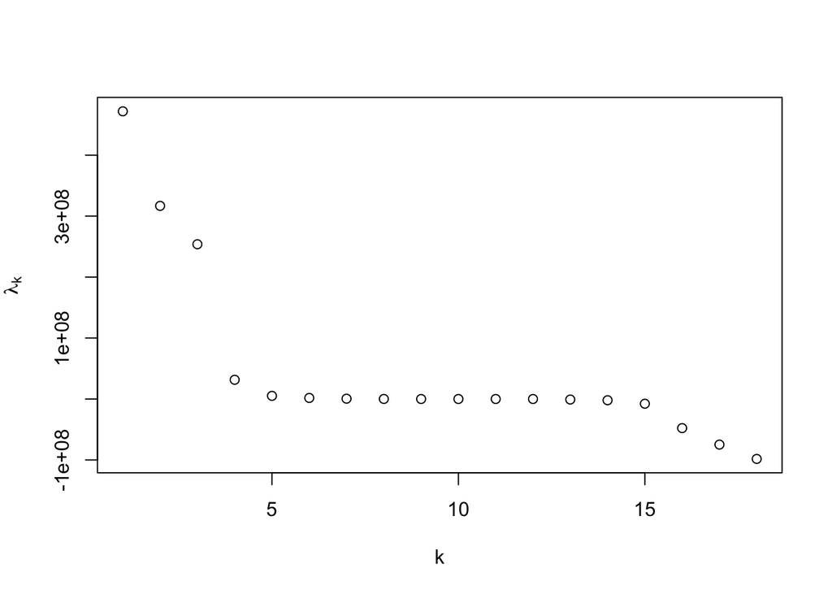

Note the presence of negative eigenvalues, which are not surprising since the distances between cities are non-Euclidean! Importantly, the eigenvalues are small in magnitude for $k>3$ suggesting a 3-dimensional representation of a the data is suitable. This is also apparent when the distance of the $k$-dimensional solution to the classical MDS is plotted against the original distances for $k=1,2,3,4.$ Below, the plots from the 3 and 4 dimensional representation are nearly identical.

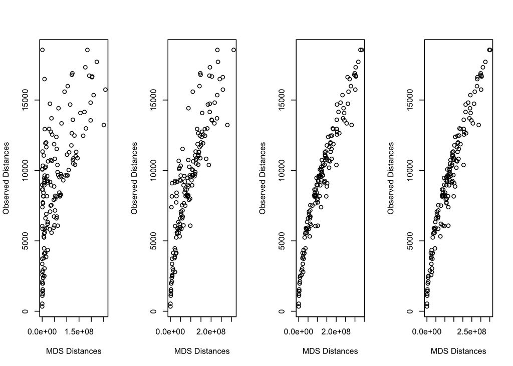

Finally, we conclude with a rendering of the classical solution in $3$ dimensions shown below. Although this image is rotated from our usual perspective, it still reflects, approximately, the orientation of cities one the globe.

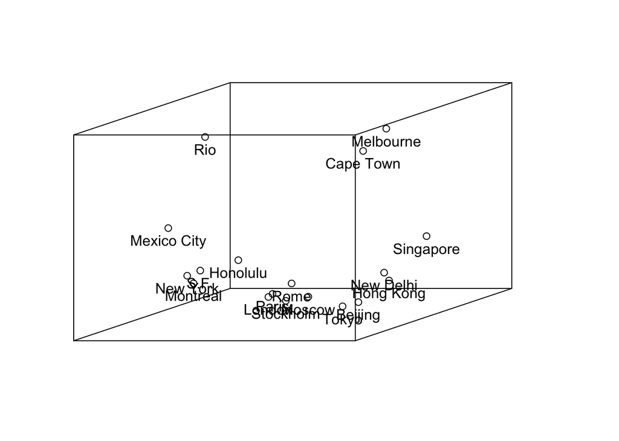

### Metris Least Squares MDS

Consider the collection of 100 points in $\mathbb{R}^2$

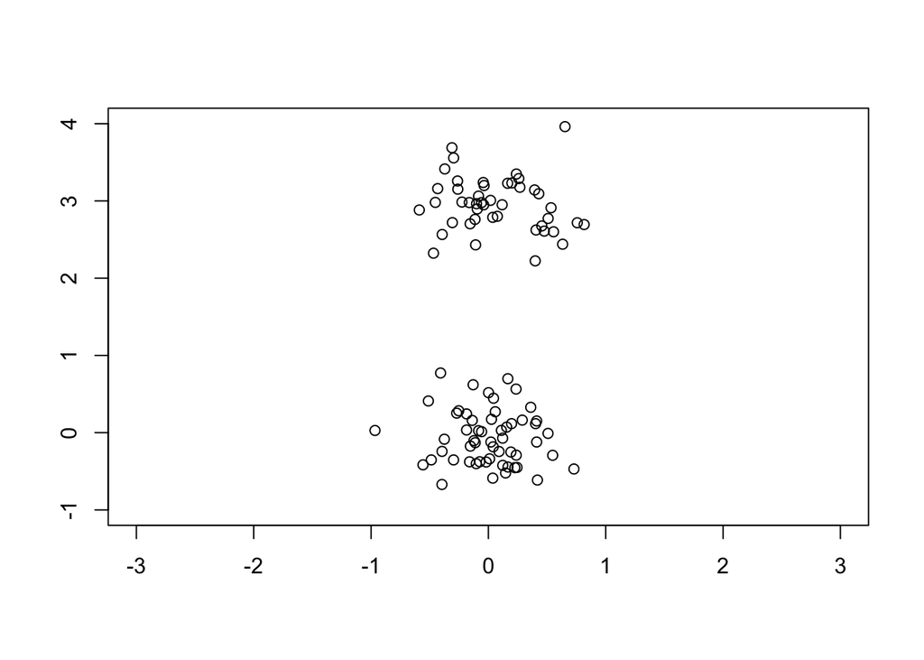

Let’s compute a one-dimensional representation of the data using metric MDS Sammon Scaling vs. Classical Scaling

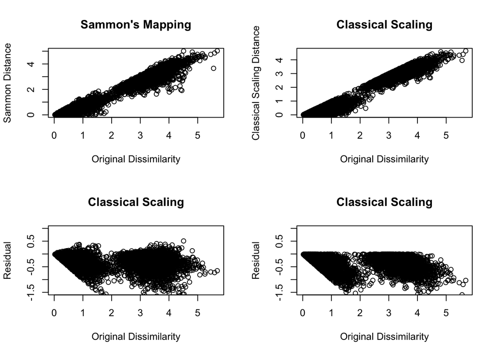

And the same figures for the Global Cities from earlier

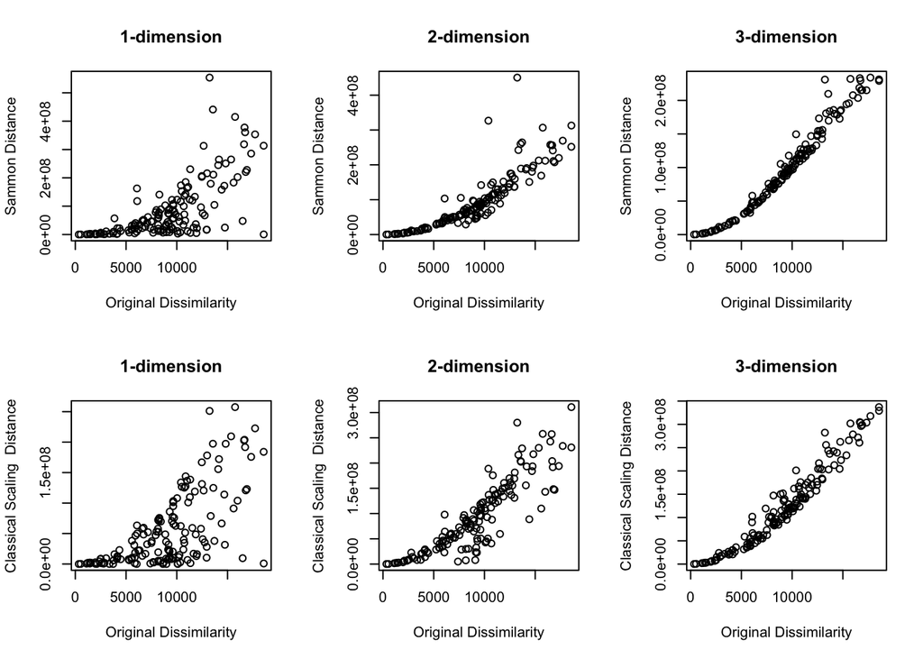

Finally, we can compare the stress at dimensions $k=1,\dots,9$, shown below.

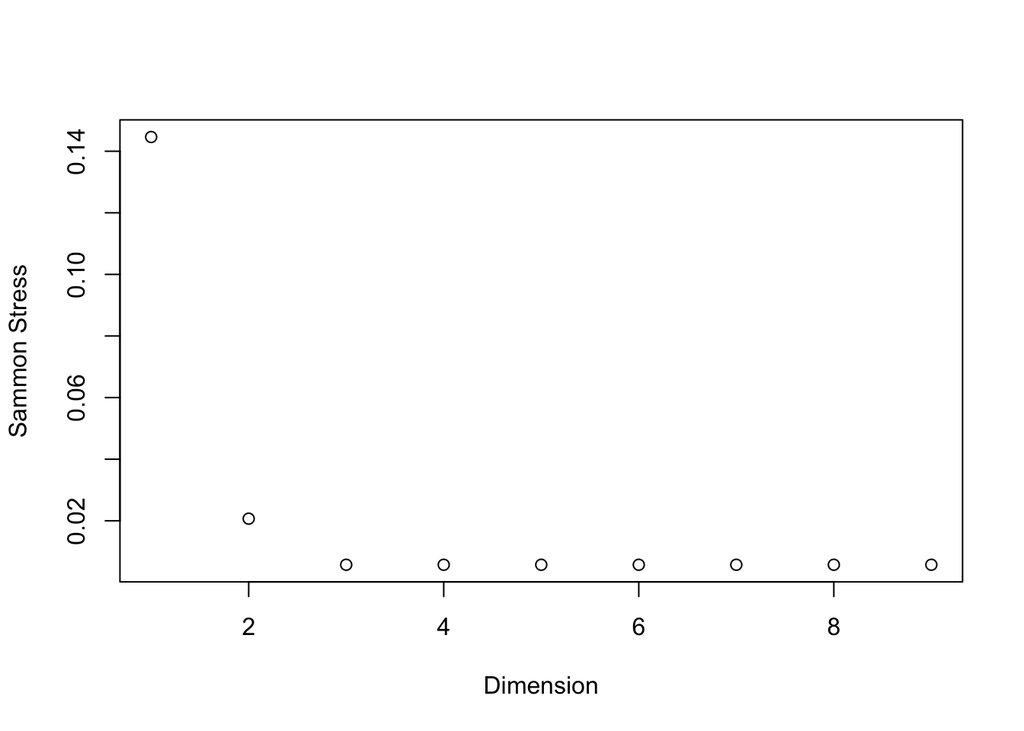

Interestingly, this metric MDS using Sammon distance shows an elbow at $k=2$ but the Sammon Stress has saturated near a small value for $k\ge 3$ dimensions. For comparison, the two-dimensional metric MDS representation of the cities (shown below) preserves the grouping of cities by continent.

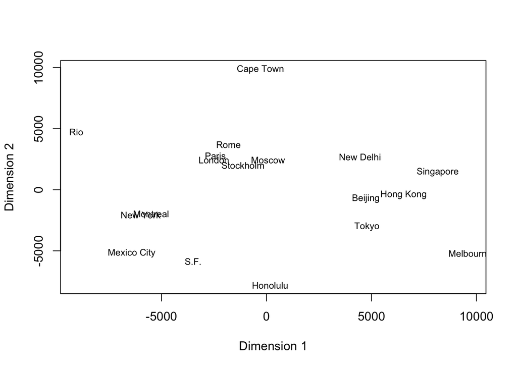

The 3-dimensional metric MDS allow preserves groupings by continent but also looks more like a traditional globe (albeit upside down from our usual representation). This result is similar but distinct from the classical MDS (compare the positions of Cape Town and Melbourne in the two cases).

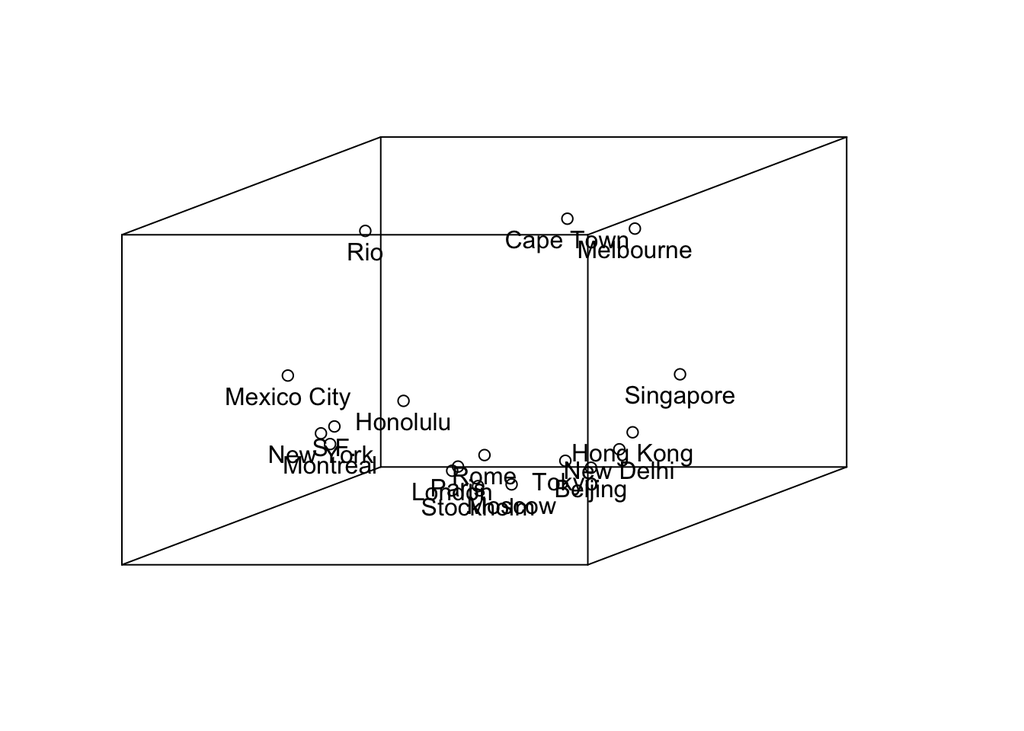

## Nonmetric MDS

As an example of nonmetric MDS, we will replicate the color circle results from Izenman. In the experiment, 14 colors were taken from the color wheel and 31 participants were asked to evaluate each pair of colors on a five-poiint scale from 0(no similarity) to 4(identical). The rating for each pair was averaged over all subjects and divided by 4 to give *similarity* ratings in the interval 0 to 1 shown below. Entries along the diagonal should be ignored.

```
##               indigo indigo-blue blue blue blue-green green green-yellow
## indigo          0.00        0.86 0.42 0.42       0.18  0.06         0.07
## indigo-blue     0.86        0.00 0.50 0.44       0.22  0.09         0.07
## blue            0.42        0.50 0.00 0.81       0.47  0.17         0.10
## blue            0.42        0.44 0.81 0.00       0.54  0.25         0.10
## blue-green      0.18        0.22 0.47 0.54       0.00  0.61         0.31
## green           0.06        0.09 0.17 0.25       0.61  0.00         0.62
## green-yellow    0.07        0.07 0.10 0.10       0.31  0.62         0.00
## yellow          0.04        0.07 0.08 0.09       0.26  0.45         0.73
## yellow-orange   0.02        0.02 0.02 0.02       0.07  0.14         0.22
## orange          0.07        0.04 0.01 0.01       0.02  0.08         0.14
## orange          0.09        0.07 0.02 0.00       0.02  0.02         0.05
## red             0.12        0.11 0.01 0.01       0.01  0.02         0.02
## red             0.13        0.13 0.05 0.02       0.02  0.02         0.02
## red             0.16        0.14 0.03 0.04       0.00  0.01         0.00
##               yellow yellow-orange orange orange  red  red  red
## indigo          0.04          0.02   0.07   0.09 0.12 0.13 0.16
## indigo-blue     0.07          0.02   0.04   0.07 0.11 0.13 0.14
## blue            0.08          0.02   0.01   0.02 0.01 0.05 0.03
## blue            0.09          0.02   0.01   0.00 0.01 0.02 0.04
## blue-green      0.26          0.07   0.02   0.02 0.01 0.02 0.00
## green           0.45          0.14   0.08   0.02 0.02 0.02 0.01
## green-yellow    0.73          0.22   0.14   0.05 0.02 0.02 0.00
## yellow          0.00          0.33   0.19   0.04 0.03 0.02 0.02
## yellow-orange   0.33          0.00   0.58   0.37 0.27 0.20 0.23
## orange          0.19          0.58   0.00   0.74 0.50 0.41 0.28
## orange          0.04          0.37   0.74   0.00 0.76 0.62 0.55
## red             0.03          0.27   0.50   0.76 0.00 0.85 0.68
## red             0.02          0.20   0.41   0.62 0.85 0.00 0.76
## red             0.02          0.23   0.28   0.55 0.68 0.76 0.00
```

We can then convert the above scores to dissimilarities through the formula *dissimilarity = 1- similarity* for all non-diagonal entries to attain the dissimilarity matrix.

```
##               indigo indigo-blue blue blue blue-green green green-yellow
## indigo          0.00        0.14 0.58 0.58       0.82  0.94         0.93
## indigo-blue     0.14        0.00 0.50 0.56       0.78  0.91         0.93
## blue            0.58        0.50 0.00 0.19       0.53  0.83         0.90
## blue            0.58        0.56 0.19 0.00       0.46  0.75         0.90
## blue-green      0.82        0.78 0.53 0.46       0.00  0.39         0.69
## green           0.94        0.91 0.83 0.75       0.39  0.00         0.38
## green-yellow    0.93        0.93 0.90 0.90       0.69  0.38         0.00
## yellow          0.96        0.93 0.92 0.91       0.74  0.55         0.27
## yellow-orange   0.98        0.98 0.98 0.98       0.93  0.86         0.78
## orange          0.93        0.96 0.99 0.99       0.98  0.92         0.86
## orange          0.91        0.93 0.98 1.00       0.98  0.98         0.95
## red             0.88        0.89 0.99 0.99       0.99  0.98         0.98
## red             0.87        0.87 0.95 0.98       0.98  0.98         0.98
## red             0.84        0.86 0.97 0.96       1.00  0.99         1.00
##               yellow yellow-orange orange orange  red  red  red
## indigo          0.96          0.98   0.93   0.91 0.88 0.87 0.84
## indigo-blue     0.93          0.98   0.96   0.93 0.89 0.87 0.86
## blue            0.92          0.98   0.99   0.98 0.99 0.95 0.97
## blue            0.91          0.98   0.99   1.00 0.99 0.98 0.96
## blue-green      0.74          0.93   0.98   0.98 0.99 0.98 1.00
## green           0.55          0.86   0.92   0.98 0.98 0.98 0.99
## green-yellow    0.27          0.78   0.86   0.95 0.98 0.98 1.00
## yellow          0.00          0.67   0.81   0.96 0.97 0.98 0.98
## yellow-orange   0.67          0.00   0.42   0.63 0.73 0.80 0.77
## orange          0.81          0.42   0.00   0.26 0.50 0.59 0.72
## orange          0.96          0.63   0.26   0.00 0.24 0.38 0.45
## red             0.97          0.73   0.50   0.24 0.00 0.15 0.32
## red             0.98          0.80   0.59   0.38 0.15 0.00 0.24
## red             0.98          0.77   0.72   0.45 0.32 0.24 0.00
```

We can now conduct nonmetric MDS using this dissimilarity matrix. The stress at dimensions 1-10 is shown below.

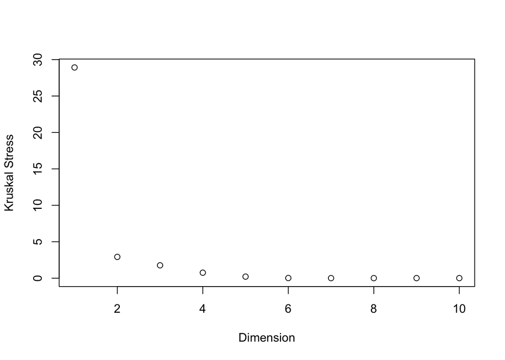

There is a clear drop in stress after 2 dimensions. If we plot the points in a two-dimensional configuration, we see the points organized in a manner similar to the standard color circle. We have deleted some of the color names to improve legibility.

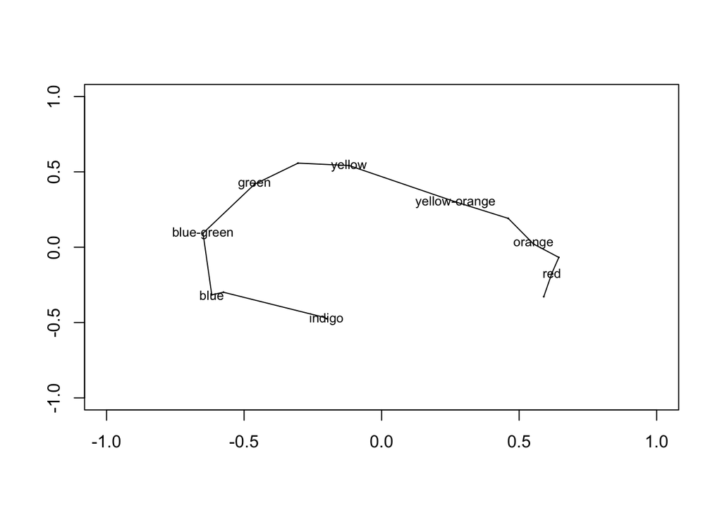